# Phase 10 — The Vaccination-to-Delivery Interval and the Maternal Responder Split

Does the interval between vaccination and delivery (in WEEKS, modelled non-linearly and interacted with arm) drive the MatBirth titres that build the responder score — and does adjusting for it attenuate the arm effect or sharpen the pre-vaccination breadth signal? Stratifier: maternal arm (TdaP vs TT) only.

Scot Zens and Anja Saso

2026-07-02

# Framing

Delivery-time (`MatBirth`) antibody in a vaccinated mother is **not a fixed quantity**: it is a point on a rise-then-decay curve whose height depends on the number of **weeks between vaccination and delivery**, `w`. Two mothers with identical intrinsic responses can land at very different `MatBirth` titres purely because one delivered near peak and the other well into decay. Because the responder score is built from `PregEarly + MatBirth` binding across PT_IgG, FHA_IgG, PRN_IgG, anything correlated with `w` could masquerade as a “predictor” of responder status when it is really proxying for interval.

This document evaluates that concern in five stages, each isolating one question so we know exactly where any change to a conclusion comes from:

- **Stage 0** — describe `w_weeks` (overall, by arm, versus the clinical covariates that alias it).
- **Stage 1** — does `w_weeks` drive `MatBirth` titres, per antigen and *per arm*? (Expect yes in TdaP, ~0 in TT.)
- **Stage 2** — build an interval-adjusted responder class (`score_adj`) and see who moves.
- **Stage 3** — re-run the Section C predictor stack with the interval forced in (arm OR; the three CV-AUCs, forced vs unforced).
- **Stage 4** — sensitivity: `score_adj` classes, a clean interval window, and preterm mothers.

```r
# Original Phase 07/08 Low/High class (full sample) via the existing engine.
mat_cls <- build_maternal_responder_class(
  data_raw, MAT_VIS, RESP_FEATS,
  breadth_thresh = params$breadth_thresh, has_cluster = has_clust)

arm_tbl <- subject_maternal_arm(data_raw)
arm_tbl$arm_name <- factor(as.character(arm_tbl$arm_name), levels = c("TT", "TdaP"))

# Per-subject interval table (subject, arm, w_weeks). Not yet filtered on w.
interval_tbl <- make_interval_tbl(arm_tbl, clin, maternal_arms = c("TT", "TdaP"))

# Interval-available analysis set: arm in {TT,TdaP} AND non-missing w_weeks.
it_avail <- interval_tbl[is.finite(interval_tbl$w_weeks), , drop = FALSE]

cat(sprintf(paste0("Mothers with a Low/High class: **%d**. With arm in {TT,TdaP}: **%d**. ",
                   "With arm AND a non-missing interval (Stage 2/3 analysis set): **%d**.\n\n"),
            nrow(mat_cls), nrow(interval_tbl), nrow(it_avail)))
```

```
## Mothers with a Low/High class: **283**. With arm in {TT,TdaP}: **312**. With arm AND a non-missing interval (Stage 2/3 analysis set): **239**.
```

# Stage 0 — Describe the interval `w_weeks`

```r
w0 <- merge(it_avail, mat_cls[, c("subject_accession", "responder")],
            by = "subject_accession", all.x = TRUE)

desc <- w0 %>%
  dplyr::group_by(arm_name) %>%
  dplyr::summarise(n = dplyr::n(),
                   median_w = round(stats::median(w_weeks), 2),
                   IQR_lo   = round(stats::quantile(w_weeks, .25), 2),
                   IQR_hi   = round(stats::quantile(w_weeks, .75), 2),
                   min_w    = round(min(w_weeks), 2),
                   max_w    = round(max(w_weeks), 2), .groups = "drop")
overall <- with(w0, data.frame(arm_name = "Overall", n = nrow(w0),
                 median_w = round(stats::median(w_weeks), 2),
                 IQR_lo = round(stats::quantile(w_weeks, .25), 2),
                 IQR_hi = round(stats::quantile(w_weeks, .75), 2),
                 min_w = round(min(w_weeks), 2), max_w = round(max(w_weeks), 2)))
print(knitr::kable(rbind(overall, desc),
  caption = "Table S10.0a. Vaccination-to-delivery interval (weeks), overall and by maternal arm."))
```

Table S10.0a. Vaccination-to-delivery interval (weeks), overall and by maternal arm.

|  | arm_name | n | median_w | IQR_lo | IQR_hi | min_w | max_w |
| --- | --- | --- | --- | --- | --- | --- | --- |
| 25% | Overall | 239 | 9.57 | 8 | 11.00 | 1.29 | 14.43 |
| 1 | TT | 122 | 9.50 | 8 | 11.14 | 3.86 | 14.00 |
| 2 | TdaP | 117 | 9.71 | 8 | 10.86 | 1.29 | 14.43 |

```r
wtest <- tryCatch(stats::wilcox.test(w_weeks ~ arm_name, data = w0), error = function(e) NULL)
cat(sprintf("\nArm imbalance in the interval: %s. %s\n\n",
    if (!is.null(wtest)) sprintf("Wilcoxon W = %.0f, p = %.3g", wtest$statistic, wtest$p.value) else "n/a",
    "If TdaP and TT mothers deliver at systematically different w, that imbalance alone would matter."))
```

Arm imbalance in the interval: Wilcoxon W = 7146, p = 0.987. If TdaP and TT mothers deliver at systematically different w, that imbalance alone would matter.

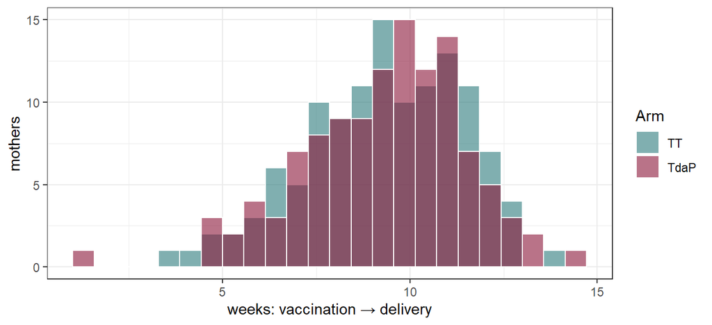

Figure S10.0. Distribution of the vaccination-to-delivery interval (weeks) by maternal arm.

```r
ggplot(w0, aes(w_weeks, fill = arm_name)) +
  geom_histogram(alpha = .6, position = "identity", bins = 24, colour = "white") +
  scale_fill_manual(values = ARM_COLS, name = "Arm") +
  labs(x = "weeks: vaccination \u2192 delivery", y = "mothers") +
  theme_bw(base_size = 11)
```

```r
# Which clinical covariates are essentially aliases of w?
alias_vars <- intersect(c("gestational_age_vaccination", "gestational_age_birth",
                          "maternal_age", "maternal_bmi", "birth_weight"),
                        names(clin))
# Merge only the alias columns; clin also carries w_weeks/w_days, so merging the
# whole frame would collide with it_avail$w_weeks (renamed to w_weeks.x/.y).
wc <- merge(it_avail, clin[, c("subject_accession", alias_vars), drop = FALSE],
            by = "subject_accession", all.x = TRUE)
al <- do.call(rbind, lapply(alias_vars, function(v) {
  x <- suppressWarnings(as.numeric(wc[[v]]))
  ok <- is.finite(x) & is.finite(wc$w_weeks)
  r  <- if (sum(ok) >= 3) round(stats::cor(x[ok], wc$w_weeks[ok]), 3) else NA_real_
  data.frame(covariate = v, n = sum(ok), pearson_r = r)
}))
al <- al[order(-abs(al$pearson_r)), , drop = FALSE]
print(knitr::kable(al, row.names = FALSE,
  caption = "Table S10.0b. Correlation of each clinical covariate with the interval (weeks). High |r| flags a covariate that is essentially an alias of w (gestational age at vaccination / at delivery are expected to be)."))
```

Table S10.0b. Correlation of each clinical covariate with the interval (weeks). High |r| flags a covariate that is essentially an alias of w (gestational age at vaccination / at delivery are expected to be).

| covariate | n | pearson_r |
| --- | --- | --- |
| gestational_age_vaccination | 239 | -0.683 |
| gestational_age_birth | 239 | 0.663 |
| birth_weight | 213 | 0.362 |
| maternal_bmi | 238 | 0.150 |
| maternal_age | 239 | -0.005 |

# Stage 1 — Does `w_weeks` drive MatBirth titres? (per antigen, per arm)

For each Stage-1 feature we fit, on the paired PregEarly→MatBirth data, `MatBirth ~ ns(w_weeks, df) * arm + PregEarly` (baseline-adjusted, so we model the *boost*), and report the fraction of residual variance explained by `w` **within each arm** plus the arm × interval interaction test.

```r
# paired_change() supplies v_from (PregEarly log10), v_to (MatBirth log10), delta,
# arm_name and subject_accession per feature — the same object the boost analysis uses.
paired <- paired_change(data_raw, params$from_visit, params$to_visit)
paired <- paired[paired$arm_name %in% c("TT", "TdaP"), , drop = FALSE]
paired$arm_name <- factor(as.character(paired$arm_name), levels = c("TT", "TdaP"))
paired <- merge(paired, it_avail[, c("subject_accession", "w_weeks")],
                by = "subject_accession", all.x = FALSE)   # interval-available only
```

```r
s1 <- boost_spline_table(paired, params$stage1_features, spline_df = params$spline_df)
print(knitr::kable(s1, row.names = FALSE,
  caption = paste0("Table S10.1. Interval effect on the MatBirth boost, per feature. ",
    "pR2_w_* = partial R2 of the ns(w) spline within each arm (variance explained ",
    "AFTER the PregEarly baseline). p_w = overall test of the whole w block; ",
    "p_interaction = arm x interval interaction. Expectation: substantial pR2_w in ",
    "TdaP, near-zero in TT, and a significant interaction for pertussis antigens.")))
```

Table S10.1. Interval effect on the MatBirth boost, per feature. pR2_w_* = partial R2 of the ns(w) spline within each arm (variance explained AFTER the PregEarly baseline). p_w = overall test of the whole w block; p_interaction = arm x interval interaction. Expectation: substantial pR2_w in TdaP, near-zero in TT, and a significant interaction for pertussis antigens.

| feature | n | df_used | n_TdaP | n_TT | pR2_w_TdaP | pR2_w_TT | p_w | p_interaction |
| --- | --- | --- | --- | --- | --- | --- | --- | --- |
| PT_IgG | 211 | 3 | 97 | 114 | 0.048 | 0.009 | 0.142 | 0.304 |
| FHA_IgG | 211 | 3 | 97 | 114 | 0.049 | 0.009 | 0.175 | 0.415 |
| PRN_IgG | 211 | 3 | 97 | 114 | 0.017 | 0.015 | 0.779 | 0.637 |
| PT_IgG1 | 175 | 3 | 81 | 94 | 0.028 | 0.002 | 0.732 | 0.678 |
| FHA_IgG1 | 175 | 3 | 81 | 94 | 0.031 | 0.012 | 0.595 | 0.619 |
| PRN_IgG1 | 175 | 3 | 81 | 94 | 0.044 | 0.005 | 0.382 | 0.437 |

```r
# Plain-language verdict computed from the table.
tdap_big <- s1$feature[which(s1$pR2_w_TdaP >= 0.05 & !is.na(s1$pR2_w_TdaP))]
cat(sprintf("\nWithin **TdaP**, the interval explains \u2265 5%% of residual MatBirth variance for: %s. ",
    if (length(tdap_big)) paste(tdap_big, collapse = ", ") else "none"))
```

Within **TdaP**, the interval explains ≥ 5% of residual MatBirth variance for: none.

```r
cat(sprintf("Median within-arm partial R2 for w: TdaP = %.3f, TT = %.3f.\n\n",
    stats::median(s1$pR2_w_TdaP, na.rm = TRUE), stats::median(s1$pR2_w_TT, na.rm = TRUE)))
```

Median within-arm partial R2 for w: TdaP = 0.037, TT = 0.009.

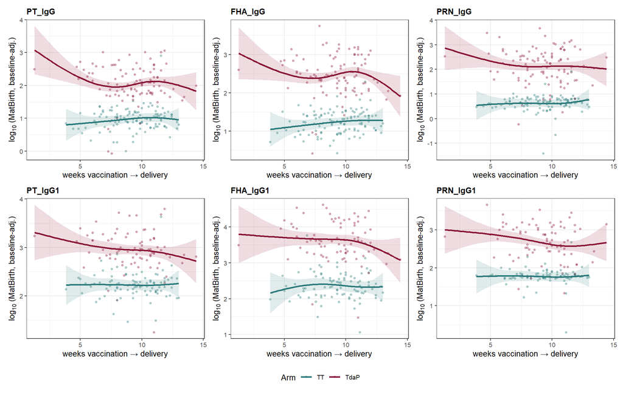

```r
p_panel <- spline_fit_panel(paired, params$stage1_features,
                            spline_df = params$spline_df, arm_cols = ARM_COLS, ncol = 3L)
if (!is.null(p_panel)) p_panel else cat("Insufficient paired data to render the spline panel.\n")
```

# Stage 2 — Interval-adjusted responder class (`score_adj`)

We residualise each of the three **score-defining** MatBirth features (PT_IgG, FHA_IgG, PRN_IgG) on `ns(w_weeks, df) * arm`, leave every PregEarly value untouched (it is pre-vaccination and cannot depend on `w`), and rebuild the class exactly as in Phase 07. To isolate the *effect of residualisation* from any change of sample, both the original and adjusted classes are rebuilt on the **same interval-available subset**.

```r
keep_ids <- it_avail$subject_accession
data_sub <- data_raw[data_raw$subject_accession %in% keep_ids, , drop = FALSE]

# Original class rebuilt on the subset (fair baseline for the comparison).
mat_cls_sub <- build_maternal_responder_class(
  data_sub, MAT_VIS, RESP_FEATS,
  breadth_thresh = params$breadth_thresh, has_cluster = has_clust)

# Interval-adjusted long object, then rebuild the class the same way.
data_adj <- residualise_matbirth(data_sub, RESP_FEATS, params$to_visit,
                                 interval_tbl = it_avail, spline_df = params$spline_df)
mat_cls_adj <- build_maternal_responder_class(
  data_adj, MAT_VIS, RESP_FEATS,
  breadth_thresh = params$breadth_thresh, has_cluster = has_clust)
```

```r
cmp <- merge(mat_cls_sub[, c("subject_accession", "responder", "score")],
             mat_cls_adj[, c("subject_accession", "responder", "score")],
             by = "subject_accession", suffixes = c("_orig", "_adj"))
tab <- table(original = cmp$responder_orig, adjusted = cmp$responder_adj)
print(knitr::kable(as.data.frame.matrix(tab),
  caption = "Table S10.2a. Original vs interval-adjusted Low/High class (same mothers)."))
```

Table S10.2a. Original vs interval-adjusted Low/High class (same mothers).

|  | Low | High |
| --- | --- | --- |
| Low | 92 | 7 |
| High | 2 | 110 |

```r
# Cohen's kappa (use irr if present, else compute directly).
po <- sum(diag(tab)) / sum(tab)
pe <- sum(rowSums(tab) * colSums(tab)) / sum(tab)^2
kappa <- (po - pe) / (1 - pe)
r_score <- stats::cor(cmp$score_orig, cmp$score_adj, use = "complete.obs")
movers <- cmp[cmp$responder_orig != cmp$responder_adj, , drop = FALSE]
cat(sprintf("\nClass agreement: **%.1f%%** (Cohen's \u03ba = **%.3f**); score correlation r = **%.3f**. ",
            100 * po, kappa, r_score))
```

Class agreement: **95.7%** (Cohen’s κ = **0.914**); score correlation r = **0.996**.

```r
cat(sprintf("**%d** mothers change class after interval adjustment.\n\n", nrow(movers)))
```

**9** mothers change class after interval adjustment.

```r
# Does the arm-only class definition survive? (Phase 08 arm-only AUC was ~0.78.)
arm_of <- merge(mat_cls_sub[, c("subject_accession","responder")],
                it_avail[, c("subject_accession","arm_name")], by = "subject_accession")
arm_oa <- merge(mat_cls_adj[, c("subject_accession","responder")],
                it_avail[, c("subject_accession","arm_name")], by = "subject_accession")
auc_arm_orig <- auc_binary(as.numeric(arm_of$arm_name == "TdaP"), arm_of$responder)
auc_arm_adj  <- auc_binary(as.numeric(arm_oa$arm_name == "TdaP"), arm_oa$responder)
cat(sprintf("Arm-only AUC for the class: original = **%.3f**, interval-adjusted = **%.3f**. ",
            auc_arm_orig, auc_arm_adj))
```

Arm-only AUC for the class: original = **0.771**, interval-adjusted = **0.780**.

```r
cat("A stable value means the Low/High definition is robust to interval; a large drop would mean much of the arm signal was interval-mediated.\n\n")
```

A stable value means the Low/High definition is robust to interval; a large drop would mean much of the arm signal was interval-mediated.

```r
if (nrow(movers)) {
  mv <- merge(movers, it_avail[, c("subject_accession","arm_name","w_weeks")],
              by = "subject_accession")
  mv <- mv[, c("subject_accession","arm_name","w_weeks","responder_orig","responder_adj")]
  mv$w_weeks <- round(mv$w_weeks, 1)
  print(knitr::kable(mv, row.names = FALSE,
    caption = "Table S10.2b. Mothers who change responder class after interval adjustment (with their arm and interval)."))
}
```

Table S10.2b. Mothers who change responder class after interval adjustment (with their arm and interval).

| subject_accession | arm_name | w_weeks | responder_orig | responder_adj |
| --- | --- | --- | --- | --- |
| 55 | TT | 11.1 | High | Low |
| 79 | TdaP | 9.4 | Low | High |
| 178 | TdaP | 6.9 | Low | High |
| 228 | TT | 7.4 | Low | High |
| 231 | TdaP | 8.4 | Low | High |
| 237 | TT | 6.9 | Low | High |
| 238 | TT | 6.9 | Low | High |
| 637 | TT | 5.0 | Low | High |
| 641 | TT | 11.4 | High | Low |

# Stage 3 — Predictor stack with the interval forced in

## Arm-adjusted logistic with a non-linear interval block

```r
d3 <- merge(mat_cls[, c("subject_accession","responder")],
            it_avail[, c("subject_accession","arm_name","w_weeks")],
            by = "subject_accession")
d3$arm_name <- factor(as.character(d3$arm_name), levels = c("TT","TdaP"))
dfw <- .safe_df(d3$w_weeks, params$spline_df)

m_arm  <- stats::glm(responder ~ arm_name, data = d3, family = binomial())
m_add  <- stats::glm(reformulate(c("arm_name",
             sprintf("ns(w_weeks, df = %d)", dfw)), "responder"),
             data = d3, family = binomial())          # additive: clean adjusted arm OR
m_full <- stats::glm(reformulate(c("arm_name",
             sprintf("ns(w_weeks, df = %d)", dfw),
             sprintf("ns(w_weeks, df = %d):arm_name", dfw)), "responder"),
             data = d3, family = binomial())           # + arm x interval interaction

print(knitr::kable(.tidy_fit(m_add, logit = TRUE),
  caption = "Table S10.3a. Arm-adjusted logistic for High responder with an additive non-linear interval term (ns(w)). This additive model gives an interpretable adjusted arm OR; the interaction model below is used only to test whether the interval effect differs by arm."))
```

Table S10.3a. Arm-adjusted logistic for High responder with an additive non-linear interval term (ns(w)). This additive model gives an interpretable adjusted arm OR; the interaction model below is used only to test whether the interval effect differs by arm.

| Predictor | est | SE | stat | p | OR | OR_lo | OR_hi | sig |
| --- | --- | --- | --- | --- | --- | --- | --- | --- |
| (Intercept) | -1.4699156 | 1.6809571 | -0.8744516 | 0.3818724 | 0.2299449 | 0.0085264 | 6.201309 | ns |
| arm_nameTdaP | 2.5946891 | 0.3483699 | 7.4480865 | 0.0000000 | 13.3924230 | 6.7658243 | 26.509259 | *** |
| ns(w_weeks, df = 3)1 | 0.8975190 | 0.9733653 | 0.9220783 | 0.3564877 | 2.4535084 | 0.3641181 | 16.532282 | ns |
| ns(w_weeks, df = 3)2 | 0.6441928 | 3.7235223 | 0.1730063 | 0.8626465 | 1.9044491 | 0.0012890 | 2813.814758 | ns |
| ns(w_weeks, df = 3)3 | 0.3127693 | 1.4298240 | 0.2187467 | 0.8268474 | 1.3672060 | 0.0829360 | 22.538487 | ns |

```r
or_arm_only <- exp(stats::coef(m_arm)["arm_nameTdaP"])
or_arm_add  <- exp(stats::coef(m_add)["arm_nameTdaP"])
ci_add <- tryCatch(exp(suppressMessages(stats::confint(m_add)))["arm_nameTdaP", ],
                   error = function(e) c(NA, NA))
lr_block <- stats::anova(m_arm, m_full, test = "LRT")   # whole interval block
lr_int   <- stats::anova(m_add, m_full, test = "LRT")   # arm x interval interaction only

cat(sprintf(paste0("\nAdjusted arm OR for High responder: **%.2f** (95%% CI %.2f\u2013%.2f) after an ",
    "additive interval spline, vs **%.2f** unadjusted \u2014 essentially unchanged. ",
    "Likelihood-ratio test for the whole interval block: %s; for the arm \u00d7 interval ",
    "interaction alone: %s. ",
    "(NB: the arm main-effect OR from the interaction model is NOT interpretable as an ",
    "adjusted OR \u2014 with arm interacting with the spline it is an extrapolation to the ",
    "spline boundary and is unstable, so it is not quoted.)\n\n"),
    or_arm_add, ci_add[1], ci_add[2], or_arm_only,
    if (!is.null(lr_block$`Pr(>Chi)`[2])) sprintf("chi2 = %.2f, p = %.3g",
        lr_block$Deviance[2], lr_block$`Pr(>Chi)`[2]) else "n/a",
    if (!is.null(lr_int$`Pr(>Chi)`[2])) sprintf("chi2 = %.2f, p = %.3g",
        lr_int$Deviance[2], lr_int$`Pr(>Chi)`[2]) else "n/a"))
```

Adjusted arm OR for High responder: **13.39** (95% CI 6.93–27.30) after an additive interval spline, vs **12.97** unadjusted — essentially unchanged. Likelihood-ratio test for the whole interval block: chi2 = 5.87, p = 0.438; for the arm × interval interaction alone: chi2 = 4.32, p = 0.229. (NB: the arm main-effect OR from the interaction model is NOT interpretable as an adjusted OR — with arm interacting with the spline it is an extrapolation to the spline boundary and is unstable, so it is not quoted.)

## Elastic-net signatures: does forcing the interval change the CV-AUCs?

The arm (always) and the `ns(w) x arm` interval block (in the forced columns) are entered **unpenalised**; serology competes for the rest. We compute each model’s CV-AUC **with and without** the interval block on the same interval-available mothers, so the two columns are directly comparable — and comparable to the Section C numbers (arm-only ≈ 0.78, arm + pre-vax breadth ≈ 0.88).

```r
if (!has_glmnet) {
  cat("> **glmnet not installed** — the penalised models are skipped. Install `glmnet` to run the CV-AUC comparison.\n\n")
} else {
  .excl_anti <- { av <- unique(as.character(data_raw$feature))
                  av[sub("_.*$", "", toupper(av)) %in% c("ACT","PENTAMER")] }
  .excl <- union(RESP_FEATS, .excl_anti)
  W_all  <- build_maternal_serology_matrix(data_raw, MAT_VIS,
              exclude_feats = .excl, min_coverage = params$min_coverage)
  W_base <- build_maternal_serology_matrix(data_raw, params$baseline_visit,
              exclude_feats = .excl, min_coverage = params$min_coverage)

  # No-serology reference rows via k-fold CV of a plain glm.
  auc_arm      <- cv_auc_glm(responder ~ arm_name, d3, nfolds = params$en_folds, seed = params$seed)
  auc_arm_w    <- cv_auc_glm(reformulate(c("arm_name",
                     sprintf("ns(w_weeks, df = %d)", dfw),
                     sprintf("ns(w_weeks, df = %d):arm_name", dfw)), "responder"),
                     d3, nfolds = params$en_folds, seed = params$seed)

  en_base_off <- en_forced(W_base, mat_cls, it_avail, force_interval = FALSE,
                   spline_df = params$spline_df, alpha = params$en_alpha,
                   nfolds = params$en_folds, seed = params$seed)
  en_base_on  <- en_forced(W_base, mat_cls, it_avail, force_interval = TRUE,
                   spline_df = params$spline_df, alpha = params$en_alpha,
                   nfolds = params$en_folds, seed = params$seed)
  en_all_off  <- en_forced(W_all,  mat_cls, it_avail, force_interval = FALSE,
                   spline_df = params$spline_df, alpha = params$en_alpha,
                   nfolds = params$en_folds, seed = params$seed)
  en_all_on   <- en_forced(W_all,  mat_cls, it_avail, force_interval = TRUE,
                   spline_df = params$spline_df, alpha = params$en_alpha,
                   nfolds = params$en_folds, seed = params$seed)

  g <- function(x) if (isTRUE(x$ok)) round(x$cv_auc, 3) else NA_real_
  cmp3 <- data.frame(
    model = c("arm only",
              "arm + ns(w) x arm",
              sprintf("arm + baseline serology (%s)", params$baseline_visit),
              "arm + all maternal serology"),
    cv_auc_no_interval = c(round(auc_arm, 3), NA, g(en_base_off), g(en_all_off)),
    cv_auc_with_interval = c(round(auc_arm, 3), round(auc_arm_w, 3), g(en_base_on), g(en_all_on)),
    n_serology_selected = c(NA, NA,
              if (isTRUE(en_base_on$ok)) en_base_on$n_serology_selected else NA,
              if (isTRUE(en_all_on$ok))  en_all_on$n_serology_selected  else NA),
    stringsAsFactors = FALSE)
  print(knitr::kable(cmp3,
    caption = paste0("Table S10.3b. Cross-validated AUC for the responder class, WITHOUT vs WITH the ",
      "interval block forced in. The pre-vaccination (", params$baseline_visit,
      ") row is the clean test: PregEarly breadth cannot be confounded by interval, so if forcing the ",
      "interval RAISES its CV-AUC, the interval was adding nuisance variance the breadth signal was fighting.")))

  d_base <- g(en_base_on) - g(en_base_off)
  cat(sprintf(paste0("\nPre-vaccination breadth CV-AUC: %.3f without interval \u2192 %.3f with interval ",
      "(\u0394 = %+.3f). %s\n\n"),
      g(en_base_off), g(en_base_on), d_base,
      if (is.finite(d_base) && d_base > 0)
        "The interval was a source of nuisance variance rather than a confounder of the breadth phenotype."
      else "Interpret alongside Stage 1 and Stage 4."))

  if (isTRUE(en_all_on$ok) && !is.null(en_all_on$coefs) && nrow(en_all_on$coefs)) {
    co <- en_all_on$coefs[order(-abs(en_all_on$coefs$coef)), , drop = FALSE]
    co$coef <- round(co$coef, 3)
    print(knitr::kable(utils::head(co, 25), row.names = FALSE,
      caption = "Table S10.3c. Non-zero elastic-net terms (arm + interval forced in; serology penalised, standardised)."))
  }
}
```

Table S10.3b. Cross-validated AUC for the responder class, WITHOUT vs WITH the interval block forced in. The pre-vaccination (PregEarly) row is the clean test: PregEarly breadth cannot be confounded by interval, so if forcing the interval RAISES its CV-AUC, the interval was adding nuisance variance the breadth signal was fighting.

| model | cv_auc_no_interval | cv_auc_with_interval | n_serology_selected |
| --- | --- | --- | --- |
| arm only | 0.711 | 0.711 | NA |
| arm + ns(w) x arm | NA | NA | NA |
| arm + baseline serology (PregEarly) | 0.842 | 0.824 | 1 |
| arm + all maternal serology | 0.844 | 0.816 | 3 |

Pre-vaccination breadth CV-AUC: 0.842 without interval → 0.824 with interval (Δ = -0.018). Interpret alongside Stage 1 and Stage 4.

Table S10.3c. Non-zero elastic-net terms (arm + interval forced in; serology penalised, standardised).

| term | coef |
| --- | --- |
| w_ns2:TdaP | -18.001 |
| armTdaP | 11.890 |
| w_ns2 | 11.194 |
| w_ns1:TdaP | -4.830 |
| w_ns1 | 3.720 |
| w_ns3 | 1.655 |
| w_ns3:TdaP | -1.000 |
| FIM_IgG@PregEarly | 0.266 |
| FIM_IgG@MatBirth | 0.192 |
| TT_IgG@MatBirth | -0.145 |

# Stage 4 — Sensitivity checks

## 4a. Use the interval-adjusted (`score_adj`) classes

```r
if (has_glmnet) {
  en_base_adj <- en_forced(W_base, mat_cls_adj, it_avail, force_interval = TRUE,
                   spline_df = params$spline_df, alpha = params$en_alpha,
                   nfolds = params$en_folds, seed = params$seed)
  en_all_adj  <- en_forced(W_all,  mat_cls_adj, it_avail, force_interval = TRUE,
                   spline_df = params$spline_df, alpha = params$en_alpha,
                   nfolds = params$en_folds, seed = params$seed)
  s4 <- data.frame(
    model = c(sprintf("arm + interval + baseline serology (%s)", params$baseline_visit),
              "arm + interval + all maternal serology"),
    cv_auc_score_adj = c(if (isTRUE(en_base_adj$ok)) round(en_base_adj$cv_auc, 3) else NA,
                         if (isTRUE(en_all_adj$ok))  round(en_all_adj$cv_auc, 3)  else NA),
    stringsAsFactors = FALSE)
  print(knitr::kable(s4,
    caption = "Table S10.4a. Stage-3 CV-AUCs recomputed against the interval-ADJUSTED responder classes. Conclusions should not hinge on which class definition is used."))
} else cat("*glmnet not installed — Stage 4a skipped.*\n\n")
```

Table S10.4a. Stage-3 CV-AUCs recomputed against the interval-ADJUSTED responder classes. Conclusions should not hinge on which class definition is used.

| model | cv_auc_score_adj |
| --- | --- |
| arm + interval + baseline serology (PregEarly) | 0.846 |
| arm + interval + all maternal serology | 0.833 |

## 4b. Clean interval window

```r
lo <- params$clean_window[1]; hi <- params$clean_window[2]
d3c <- d3[d3$w_weeks >= lo & d3$w_weeks <= hi, , drop = FALSE]
cat(sprintf("Restricting to w_weeks \u2208 [%g, %g]: **%d** mothers (of %d).\n\n",
            lo, hi, nrow(d3c), nrow(d3)))
```

Restricting to w_weeks ∈ [2, 12]: **197** mothers (of 211).

```r
if (has_glmnet && nrow(d3c) > (params$en_folds + 15L)) {
  itc <- it_avail[it_avail$w_weeks >= lo & it_avail$w_weeks <= hi, , drop = FALSE]
  en_base_win <- en_forced(W_base, mat_cls, itc, force_interval = TRUE,
                   spline_df = params$spline_df, alpha = params$en_alpha,
                   nfolds = params$en_folds, seed = params$seed)
  cat(sprintf("Pre-vaccination breadth CV-AUC within the clean window: **%s**. ",
      if (isTRUE(en_base_win$ok)) sprintf("%.3f", en_base_win$cv_auc) else "n/a"))
  cat("The pre-vax breadth signal should survive if it is a genuine pre-existing trait.\n\n")
} else cat("*Insufficient N in the clean window (or glmnet missing) for the penalised check.*\n\n")
```

Pre-vaccination breadth CV-AUC within the clean window: **0.812**. The pre-vax breadth signal should survive if it is a genuine pre-existing trait.

## 4c. Preterm mothers

```r
if ("gestational_age_birth" %in% names(clin)) {
  pt <- merge(it_avail, clin[, c("subject_accession","gestational_age_birth")],
              by = "subject_accession")
  pt$gestational_age_birth <- suppressWarnings(as.numeric(pt$gestational_age_birth))
  pt$preterm <- ifelse(pt$gestational_age_birth < params$preterm_ga, "preterm (<37w)", "term")
  ptt <- pt %>% dplyr::filter(!is.na(preterm)) %>%
    dplyr::group_by(preterm) %>%
    dplyr::summarise(n = dplyr::n(), median_w = round(stats::median(w_weeks), 2),
                     .groups = "drop")
  print(knitr::kable(ptt,
    caption = "Table S10.4b. Interval by preterm status. Preterm mothers mechanically have a shorter vaccination-to-delivery interval, so they are a natural check on interval-driven artefacts."))
} else cat("*gestational_age_birth not available — preterm check skipped.*\n\n")
```

Table S10.4b. Interval by preterm status. Preterm mothers mechanically have a shorter vaccination-to-delivery interval, so they are a natural check on interval-driven artefacts.

| preterm | n | median_w |
| --- | --- | --- |
| preterm (<37w) | 12 | 6.36 |
| term | 227 | 9.71 |

# Synthesis

```r
cat("Read Stages 0\u20134 together to answer the three framing questions:\n\n")
```

Read Stages 0–4 together to answer the three framing questions:

```r
cat("1. **Is the interval a real driver of MatBirth pertussis titres?** \u2014 Table S10.1 / Figure S10.1 (expect yes in TdaP, ~0 in TT).\n")
```

1. **Is the interval a real driver of MatBirth pertussis titres?** — Table S10.1 / Figure S10.1 (expect yes in TdaP, ~0 in TT).

```r
cat("2. **Does adjusting for interval attenuate the responder signal?** \u2014 Stage 2 (\u03ba, movers, arm-only AUC) and Table S10.3a (arm OR before/after).\n")
```

2. **Does adjusting for interval attenuate the responder signal?** — Stage 2 (κ, movers, arm-only AUC) and Table S10.3a (arm OR before/after).

```r
cat("3. **Does adjusting for interval sharpen the pre-existing breadth phenotype?** \u2014 the pre-vaccination row of Table S10.3b (does the ~0.88 CV-AUC rise when interval is forced in?).\n\n")
```

3. **Does adjusting for interval sharpen the pre-existing breadth phenotype?** — the pre-vaccination row of Table S10.3b (does the ~0.88 CV-AUC rise when interval is forced in?).

```r
cat(sprintf("Interval-available analysis set: **%d** mothers (TdaP = %d, TT = %d).\n\n",
    nrow(it_avail), sum(it_avail$arm_name == "TdaP"), sum(it_avail$arm_name == "TT")))
```

Interval-available analysis set: **239** mothers (TdaP = 117, TT = 122).

```r
if (!is.null(nt) && exists("nt_render", mode = "function"))
  tryCatch(nt_render(nt, caption = "Participant accounting for Phase 10."),
           error = function(e) invisible(NULL))
```

*No models logged.*

*Phase 10 branch. Interval modelled in WEEKS with a natural cubic spline (df = 3; df = 4 available as a sensitivity via `params$spline_df_sens`) interacted with arm. The Phase 07/08 engines are sourced read-only; all new logic lives in `R/interval_helpers.R`. Knit both formats with* `rmarkdown::render("10_interval_adjusted_responder.Rmd", output_format = "all")`.